# Casal2 Test Case comparisons for BCO

# 1 BCO comparison of CASAL and Casal2 model configurations

This document compares the results of at least 2 CASAL model configurations (base and at least one sensitivity) and up to 8 Casal2 model configurations (3 BetaDiff, 2 CppAD, and 3 ADOL-C).

The CASAL model sensitivity 1 has a smaller tolerance value than the CASAL base model (1e-7 vs. 2e-5).

The Casal2 ADOL-C and BetaDiff low tolerance models have a smaller tolerance value than the CASAL base model (1e-7 vs. 2e-5). The Casal2 CppAD models have a tolerance value of 1e-9.

## 1.1 BCO model characteristics

The main characteristics of the Test Case BCO (ling) CASAL model are:

- one stock, ages 3 - 20
- one area
- years 1900 - 2019, projection year 2020
- one time step
- two stock categories: male and female
- natural mortality-at-age is 0.14 for males and 0.20 for females
- sex-specific logistic maturity
- sex-specific von Bertalanffy age-length relationship
- one length-weight relationship ($W = aL^b$)
- Beverton-Holt stock-recruitment relationship, with steepness (h) 0.75 and $\sigma_R$ 0.6
- no ageing error
- one survey with sex-specific age-based logistic selectivity
- three fisheries, all with sex-specific length-based logistic selectivity and retained/discarded catches

Parameters estimated include:

- B0
- male $L_{\infty}$
- male age-length CV2
- sex-specific survey logistic selectivity (a50 and ato95)
- YCS (recruitment deviations)

## 1.3 CASAL and Casal2 model output

```r
source('../../R-functions/report_read_in_CASAL_MPD_files.R')
```

```r
source('../../R-functions/report_read_in_Casal2_MPD_files.R')
```

## 1.4 Tables

Tables of parameter estimates and objective function components for the CASAL and Casal2 model MPD results

CASAL parameter estimates

| rownames | Base_Model | Sensitivity_1 | Percent_Diff |
| --- | --- | --- | --- |
| initialization.B0 | 14170.00000 | 14170.00000 | 0.000 |
| recruitment.YCS1 | 1.00000 | 1.00000 | 0.000 |
| recruitment.YCS2 | 1.00000 | 1.00000 | 0.000 |
| recruitment.YCS3 | 1.00000 | 1.00000 | 0.000 |
| recruitment.YCS4 | 1.00000 | 1.00000 | 0.000 |
| recruitment.YCS5 | 1.00000 | 1.00000 | 0.000 |
| recruitment.YCS6 | 1.00000 | 1.00000 | 0.000 |
| recruitment.YCS7 | 1.00000 | 1.00000 | 0.000 |
| recruitment.YCS8 | 1.00000 | 1.00000 | 0.000 |
| recruitment.YCS9 | 1.00000 | 1.00000 | 0.000 |
| recruitment.YCS10 | 1.00000 | 1.00000 | 0.000 |
| recruitment.YCS11 | 1.00000 | 1.00000 | 0.000 |
| recruitment.YCS12 | 1.00000 | 1.00000 | 0.000 |
| recruitment.YCS13 | 1.00000 | 1.00000 | 0.000 |
| recruitment.YCS14 | 1.00000 | 1.00000 | 0.000 |
| recruitment.YCS15 | 1.00000 | 1.00000 | 0.000 |
| recruitment.YCS16 | 1.00000 | 1.00000 | 0.000 |
| recruitment.YCS17 | 1.00000 | 1.00000 | 0.000 |
| recruitment.YCS18 | 1.00000 | 1.00000 | 0.000 |
| recruitment.YCS19 | 1.00000 | 1.00000 | 0.000 |
| recruitment.YCS20 | 1.00000 | 1.00000 | 0.000 |
| recruitment.YCS21 | 1.00000 | 1.00000 | 0.000 |
| recruitment.YCS22 | 1.00000 | 1.00000 | 0.000 |
| recruitment.YCS23 | 1.00000 | 1.00000 | 0.000 |
| recruitment.YCS24 | 1.00000 | 1.00000 | 0.000 |
| recruitment.YCS25 | 1.00000 | 1.00000 | 0.000 |
| recruitment.YCS26 | 1.00000 | 1.00000 | 0.000 |
| recruitment.YCS27 | 1.00000 | 1.00000 | 0.000 |
| recruitment.YCS28 | 1.00000 | 1.00000 | 0.000 |
| recruitment.YCS29 | 1.00000 | 1.00000 | 0.000 |

[output cut: 97 more lines]

Casal2 parameter estimates

| rownames | betadiff_casal_flags_on | betadiff_casal_flags_off | betadiff_casal_flags_on_low_tol |
| --- | --- | --- | --- |
| process[Recruitment].b0 | 14199.60000 | 14210.70000 | 14199.60000 |
| age_length[asMm0].linf | 47.33060 | 47.31350 | 47.33060 |
| age_length[asMm0].cv_last | 0.05978 | 0.06142 | 0.05978 |
| selectivity[potSurveySel_male].a50 | 3.03935 | 3.04011 | 3.03932 |
| selectivity[potSurveySel_male].ato95 | 0.19078 | 0.19176 | 0.19061 |
| selectivity[potSurveySel_female].a50 | 3.31449 | 3.31509 | 3.31450 |
| selectivity[potSurveySel_female].ato95 | 1.03324 | 1.02647 | 1.03325 |
| process[Recruitment].ycs_values{1980} | 0.23522 | 0.23512 | 0.23522 |
| process[Recruitment].ycs_values{1981} | 0.23218 | 0.23209 | 0.23218 |
| process[Recruitment].ycs_values{1982} | 0.23321 | 0.23317 | 0.23321 |
| process[Recruitment].ycs_values{1983} | 0.24199 | 0.24199 | 0.24199 |
| process[Recruitment].ycs_values{1984} | 0.26464 | 0.26470 | 0.26464 |
| process[Recruitment].ycs_values{1985} | 0.31484 | 0.31495 | 0.31484 |
| process[Recruitment].ycs_values{1986} | 0.41617 | 0.41635 | 0.41617 |
| process[Recruitment].ycs_values{1987} | 0.60174 | 0.60199 | 0.60174 |
| process[Recruitment].ycs_values{1988} | 0.90212 | 0.90257 | 0.90212 |
| process[Recruitment].ycs_values{1989} | 1.37833 | 1.37987 | 1.37833 |
| process[Recruitment].ycs_values{1990} | 1.56002 | 1.55856 | 1.56001 |
| process[Recruitment].ycs_values{1991} | 1.02890 | 1.02850 | 1.02891 |
| process[Recruitment].ycs_values{1992} | 0.84788 | 0.84782 | 0.84788 |
| process[Recruitment].ycs_values{1993} | 0.84686 | 0.84708 | 0.84685 |
| process[Recruitment].ycs_values{1994} | 1.06536 | 1.06575 | 1.06536 |
| process[Recruitment].ycs_values{1995} | 1.54897 | 1.54805 | 1.54897 |
| process[Recruitment].ycs_values{1996} | 1.05329 | 1.05345 | 1.05327 |
| process[Recruitment].ycs_values{1997} | 0.80305 | 0.80290 | 0.80306 |
| process[Recruitment].ycs_values{1998} | 0.81669 | 0.81658 | 0.81669 |
| process[Recruitment].ycs_values{1999} | 0.62838 | 0.62894 | 0.62838 |
| process[Recruitment].ycs_values{2000} | 0.80206 | 0.80234 | 0.80206 |
| process[Recruitment].ycs_values{2001} | 0.74581 | 0.74599 | 0.74581 |
| process[Recruitment].ycs_values{2002} | 0.46713 | 0.46675 | 0.46713 |
| process[Recruitment].ycs_values{2003} | 1.09423 | 1.09063 | 1.09423 |
| process[Recruitment].ycs_values{2004} | 0.92128 | 0.91711 | 0.92128 |
| process[Recruitment].ycs_values{2005} | 0.38413 | 0.38256 | 0.38413 |
| process[Recruitment].ycs_values{2006} | 0.90589 | 0.90190 | 0.90589 |
| process[Recruitment].ycs_values{2007} | 0.70981 | 0.72045 | 0.70981 |
| process[Recruitment].ycs_values{2008} | 0.83557 | 0.83479 | 0.83557 |
| process[Recruitment].ycs_values{2009} | 0.42630 | 0.42606 | 0.42629 |
| process[Recruitment].ycs_values{2010} | 1.28746 | 1.28707 | 1.28746 |
| process[Recruitment].ycs_values{2011} | 0.69033 | 0.69110 | 0.69033 |
| process[Recruitment].ycs_values{2012} | 0.73638 | 0.73678 | 0.73638 |
| process[Recruitment].ycs_values{2013} | 0.56156 | 0.56190 | 0.56156 |
| process[Recruitment].ycs_values{2014} | 0.43978 | 0.43978 | 0.43978 |

Casal2 parameter estimates: Percent Difference from betadiff_casal_flags_on

| rownames | betadiff_casal_flags_on | betadiff_casal_flags_off | betadiff_casal_flags_on_low_tol |
| --- | --- | --- | --- |
| process[Recruitment].b0 | 0.000 | -0.078 | 0.000 |
| age_length[asMm0].linf | 0.000 | 0.036 | 0.000 |
| age_length[asMm0].cv_last | 0.000 | -2.757 | 0.000 |
| selectivity[potSurveySel_male].a50 | 0.000 | -0.025 | 0.001 |
| selectivity[potSurveySel_male].ato95 | 0.000 | -0.518 | 0.085 |
| selectivity[potSurveySel_female].a50 | 0.000 | -0.018 | -0.000 |
| selectivity[potSurveySel_female].ato95 | 0.000 | 0.655 | -0.001 |
| process[Recruitment].ycs_values{1980} | 0.000 | 0.045 | 0.000 |
| process[Recruitment].ycs_values{1981} | 0.000 | 0.037 | 0.000 |
| process[Recruitment].ycs_values{1982} | 0.000 | 0.019 | 0.000 |
| process[Recruitment].ycs_values{1983} | 0.000 | -0.002 | 0.000 |
| process[Recruitment].ycs_values{1984} | 0.000 | -0.021 | 0.000 |
| process[Recruitment].ycs_values{1985} | 0.000 | -0.035 | 0.000 |
| process[Recruitment].ycs_values{1986} | 0.000 | -0.042 | 0.000 |
| process[Recruitment].ycs_values{1987} | 0.000 | -0.042 | -0.000 |
| process[Recruitment].ycs_values{1988} | 0.000 | -0.049 | 0.001 |
| process[Recruitment].ycs_values{1989} | 0.000 | -0.112 | 0.000 |
| process[Recruitment].ycs_values{1990} | 0.000 | 0.094 | 0.001 |
| process[Recruitment].ycs_values{1991} | 0.000 | 0.039 | -0.001 |
| process[Recruitment].ycs_values{1992} | 0.000 | 0.007 | 0.000 |
| process[Recruitment].ycs_values{1993} | 0.000 | -0.027 | 0.001 |
| process[Recruitment].ycs_values{1994} | 0.000 | -0.037 | 0.000 |
| process[Recruitment].ycs_values{1995} | 0.000 | 0.059 | 0.000 |
| process[Recruitment].ycs_values{1996} | 0.000 | -0.015 | 0.002 |
| process[Recruitment].ycs_values{1997} | 0.000 | 0.018 | -0.001 |
| process[Recruitment].ycs_values{1998} | 0.000 | 0.014 | -0.000 |
| process[Recruitment].ycs_values{1999} | 0.000 | -0.089 | 0.000 |
| process[Recruitment].ycs_values{2000} | 0.000 | -0.035 | 0.000 |
| process[Recruitment].ycs_values{2001} | 0.000 | -0.024 | 0.000 |
| process[Recruitment].ycs_values{2002} | 0.000 | 0.080 | 0.000 |
| process[Recruitment].ycs_values{2003} | 0.000 | 0.329 | 0.000 |
| process[Recruitment].ycs_values{2004} | 0.000 | 0.453 | 0.000 |
| process[Recruitment].ycs_values{2005} | 0.000 | 0.408 | 0.000 |
| process[Recruitment].ycs_values{2006} | 0.000 | 0.440 | 0.000 |
| process[Recruitment].ycs_values{2007} | 0.000 | -1.499 | 0.000 |
| process[Recruitment].ycs_values{2008} | 0.000 | 0.093 | 0.000 |
| process[Recruitment].ycs_values{2009} | 0.000 | 0.054 | 0.000 |
| process[Recruitment].ycs_values{2010} | 0.000 | 0.030 | 0.000 |
| process[Recruitment].ycs_values{2011} | 0.000 | -0.111 | 0.000 |
| process[Recruitment].ycs_values{2012} | 0.000 | -0.054 | 0.000 |
| process[Recruitment].ycs_values{2013} | 0.000 | -0.062 | 0.000 |
| process[Recruitment].ycs_values{2014} | 0.000 | 0.001 | 0.000 |

CASAL objective function component values

| Component | Base_Model | Sensitivity_1 |
| --- | --- | --- |
| potCPUE | -51.180 | -51.180 |
| potSurveyAbd | -3.254 | -3.254 |
| logbookLF | 54.660 | 54.660 |
| potCommAF | 54.410 | 54.410 |
| potSurveyAF | 118.200 | 118.200 |
| recCatchLF | 68.040 | 68.040 |
| prior_on_initialization.B0 | 9.559 | 9.559 |
| prior_on_recruitment.YCS | 9.658 | 9.658 |
| prior_on_size_at_age.Linf_male | 0.000 | 0.000 |
| prior_on_size_at_age.cv2_male | 0.000 | 0.000 |
| prior_on_selectivity[potSsel].male | 0.000 | 0.000 |
| prior_on_selectivity[potSsel].female | 0.000 | 0.000 |
| prior_on_q_qPotCPUE | -8.331 | -8.331 |
| prior_on_q_potSurveyq | -11.380 | -11.380 |
| clp1F | 0.000 | 0.000 |
| clp2F | 0.000 | 0.000 |
| clp3F | 0.000 | 0.000 |
| YCS | 0.566 | 0.566 |
| Total | 241.000 | 241.000 |

Casal2 objective function component values

| rownames | betadiff_casal_flags_on | betadiff_casal_flags_off | betadiff_casal_flags_on_low_tol |
| --- | --- | --- | --- |
| observation->potSurvey-2010 | -1.038 | -1.042 | -1.038 |
| observation->potSurvey-2014 | -1.020 | -1.022 | -1.020 |
| observation->potSurvey-2018 | -1.196 | -1.197 | -1.196 |
| observation->potCPUE-1990 | -0.162 | -0.159 | -0.162 |
| observation->potCPUE-1991 | 1.098 | 1.102 | 1.098 |
| observation->potCPUE-1992 | -1.057 | -1.053 | -1.057 |
| observation->potCPUE-1993 | -1.991 | -1.990 | -1.991 |
| observation->potCPUE-1994 | -2.144 | -2.143 | -2.144 |
| observation->potCPUE-1995 | -2.085 | -2.085 | -2.085 |
| observation->potCPUE-1996 | -2.186 | -2.186 | -2.186 |
| observation->potCPUE-1997 | -1.960 | -1.959 | -1.960 |
| observation->potCPUE-1998 | -2.157 | -2.157 | -2.157 |
| observation->potCPUE-1999 | -1.689 | -1.689 | -1.689 |
| observation->potCPUE-2000 | -2.192 | -2.192 | -2.192 |
| observation->potCPUE-2001 | -2.164 | -2.164 | -2.164 |
| observation->potCPUE-2002 | -2.042 | -2.042 | -2.042 |
| observation->potCPUE-2003 | -2.172 | -2.173 | -2.172 |
| observation->potCPUE-2004 | -2.192 | -2.192 | -2.192 |
| observation->potCPUE-2005 | -1.908 | -1.911 | -1.908 |
| observation->potCPUE-2006 | -1.793 | -1.797 | -1.793 |
| observation->potCPUE-2007 | -2.176 | -2.177 | -2.176 |
| observation->potCPUE-2008 | -2.188 | -2.189 | -2.188 |
| observation->potCPUE-2009 | -2.051 | -2.051 | -2.051 |
| observation->potCPUE-2010 | -2.122 | -2.124 | -2.122 |
| observation->potCPUE-2011 | -1.875 | -1.865 | -1.875 |
| observation->potCPUE-2012 | -1.767 | -1.756 | -1.767 |
| observation->potCPUE-2013 | -1.775 | -1.769 | -1.775 |
| observation->potCPUE-2014 | -1.038 | -1.034 | -1.038 |
| observation->potCPUE-2015 | -1.851 | -1.851 | -1.851 |
| observation->potCPUE-2016 | -2.092 | -2.092 | -2.092 |

[output cut: 55 more lines]

```
## [1] "CASAL base model convergence information"
## [1] "Minimiser convergence threshold: 2e-05"
## [2] "fmm: have converged: t = 1.5378e-05 f = 240.986"
## [3] "Successful convergence in optimise"
## [4] "Minimiser achieved convergence after 91 quasi-Newton iterations using 101 objective function evaluations"
## [1] ""
## [1] "CASAL sensitivity 1 model convergence information"
## [1] "Minimiser convergence threshold: 1e-07"
## [2] "fmm: step size too small. Indicates successful convergence (though this is not the textbook ideal convergence situation)"
## [3] "Successful convergence in optimise"
## [4] "Minimiser achieved convergence after 99 quasi-Newton iterations using 116 objective function evaluations"
## [1] ""
## [1] "Casal2 betadiff_casal_flags_on model convergence information"
## [1] "fmm: have converged: t = 4.14847e-06 f = 238.37"
## [2] "Successful convergence in optimise"
## [1] ""
## [1] "Casal2 betadiff_casal_flags_off model convergence information"
## [1] "fmm: have converged: t = 2.71219e-06 f = 239.365"
## [2] "Successful convergence in optimise"
## [1] ""
## [1] "Casal2 betadiff_casal_flags_on_low_tol model convergence information"
## [1] "fmm: have converged: t = 5.45879e-09 f = 238.37"
## [2] "Successful convergence in optimise"
```

```
## [1] "CASAL model warnings"
## NULL
## [1] ""
## [1] "CASAL sensitivity 1 model warnings"
## NULL
## [1] ""
## [1] "Casal2 betadiff_casal_flags_on model warnings"
## $warnings_found
## [1] 1
##
## $warning_0
## [1] "Estimates were removed because of matching lower and upper bounds. Originally had 127 estimates, now have 42"
##
## $type
## [1] "warnings"
##
## [1] ""
## [1] "Casal2 betadiff_casal_flags_off model warnings"
## $warnings_found
## [1] 1
##
## $warning_0
## [1] "Estimates were removed because of matching lower and upper bounds. Originally had 127 estimates, now have 42"
##
## $type
## [1] "warnings"
##
## [1] ""
## [1] "Casal2 betadiff_casal_flags_on_low_tol model warnings"
## $warnings_found
## [1] 1
##
## $warning_0
## [1] "Estimates were removed because of matching lower and upper bounds. Originally had 127 estimates, now have 42"
##
## $type
## [1] "warnings"
```

## 1.5 Matching of outputs

Time series comparisons with CASAL base model results

```
## [1] "Catch time series base model comparison for run betadiff_casal_flags_on"
## [1] "Removals / Actual catches for line match: no"
## [1] "Discarded catches for line match: no"
## [1] "Removals / Actual catches for pot match: no"
## [1] "Discarded catches for pot match: no"
## [1] "Removals / Actual catches for rec match: no"
## [1] "Discarded catches for rec match: no"
## [1] ""
## [1] "Catch time series base model comparison for run betadiff_casal_flags_off"
## [1] "Removals / Actual catches for line match: no"
## [1] "Discarded catches for line match: no"
## [1] "Removals / Actual catches for pot match: no"
## [1] "Discarded catches for pot match: no"
## [1] "Removals / Actual catches for rec match: no"
## [1] "Discarded catches for rec match: no"
## [1] ""
## [1] "Catch time series base model comparison for run betadiff_casal_flags_on_low_tol"
## [1] "Removals / Actual catches for line match: no"
## [1] "Discarded catches for line match: no"
## [1] "Removals / Actual catches for pot match: no"
## [1] "Discarded catches for pot match: no"
## [1] "Removals / Actual catches for rec match: no"
## [1] "Discarded catches for rec match: no"
## [1] ""
```

## 1.6 Plots

Comparison plots

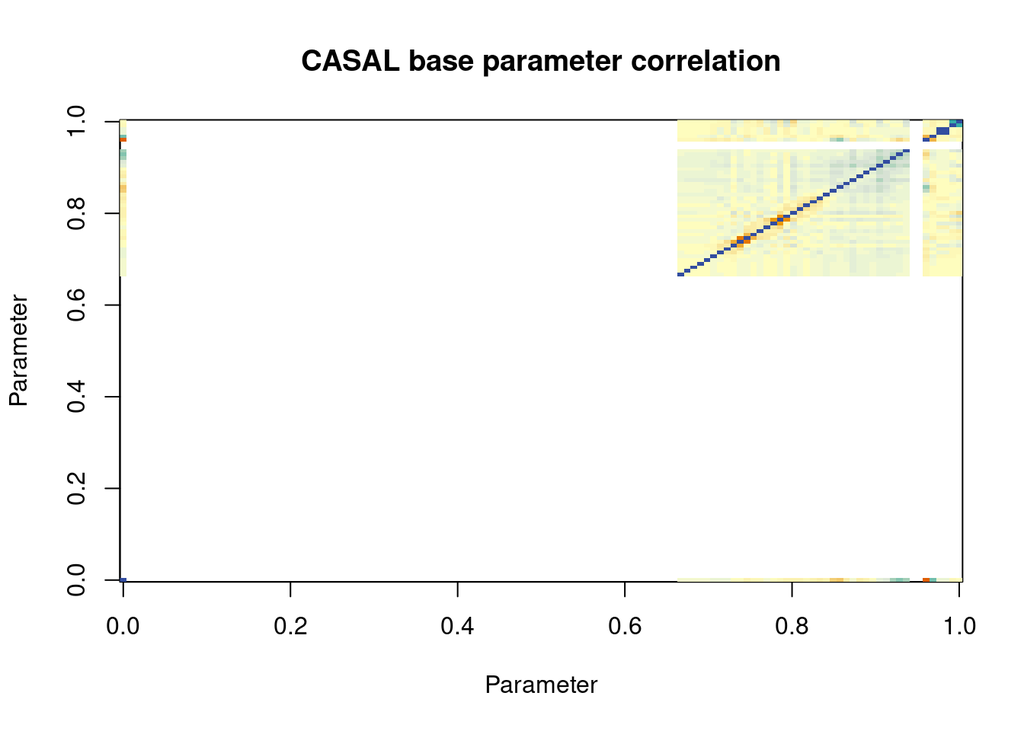

```
## [1] "CASAL base parameter correlation range (excluding 1.0): -0.6876 0.9999"
```

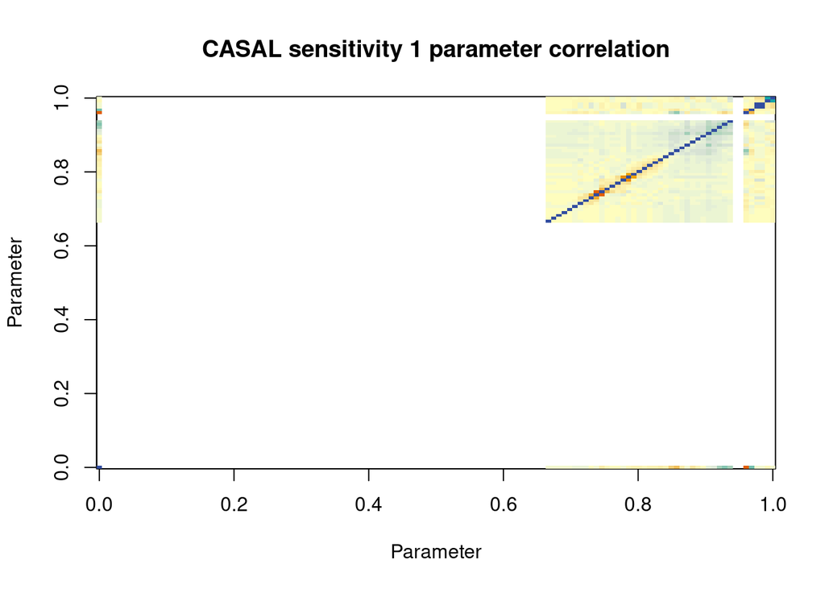

```
## [1] "CASAL sensitivity 1 parameter correlation range (excluding 1.0): -0.6894 0.9999"
```

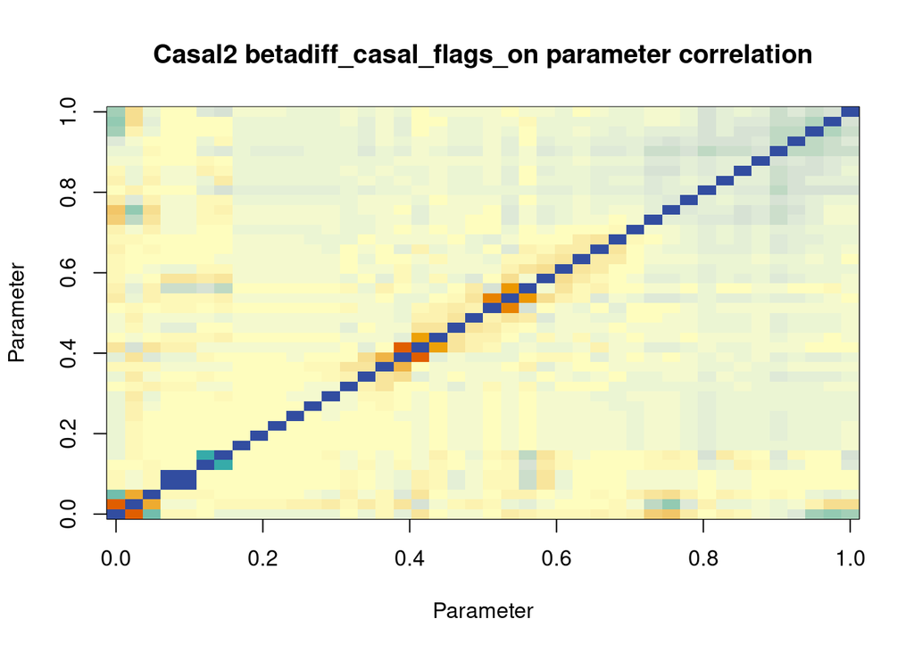

```
## [1] "Casal2 betadiff_casal_flags_on parameter correlation range (excluding 1.0): -0.704678943460098 0.99982049372598"
```

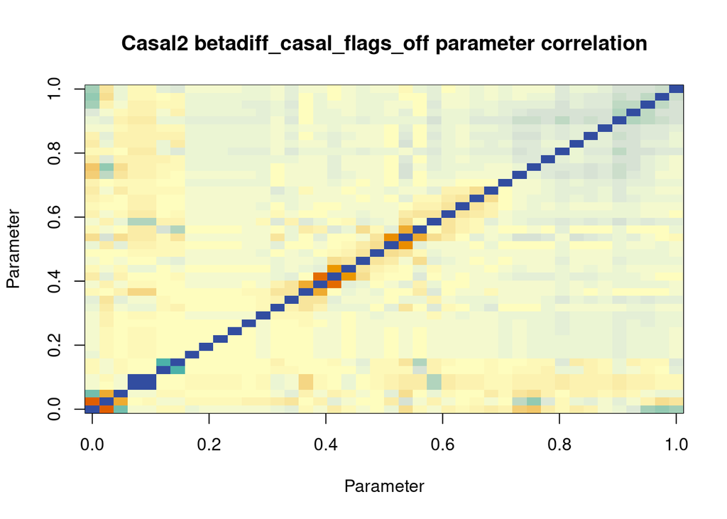

```
## [1] "Casal2 betadiff_casal_flags_off parameter correlation range (excluding 1.0): -0.697745743037247 0.999863100354264"
```

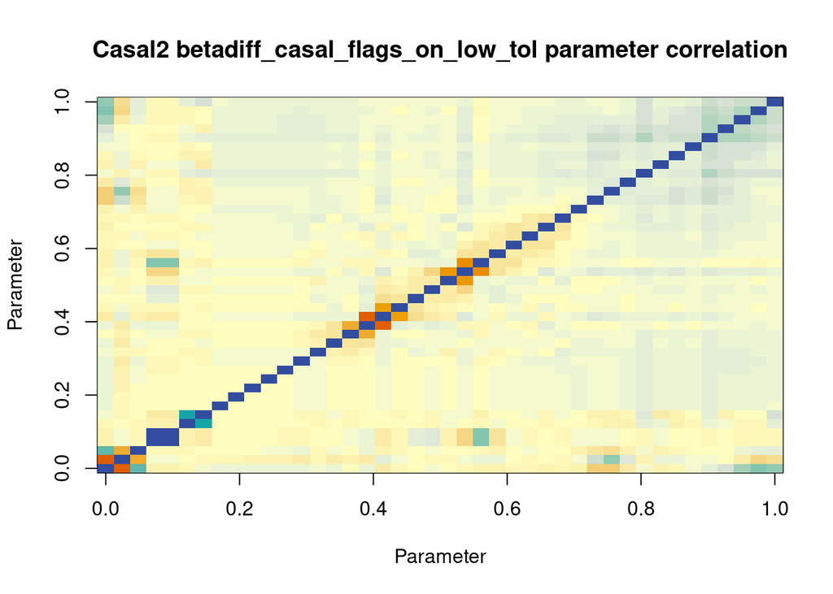

```
## [1] "Casal2 betadiff_casal_flags_on_low_tol parameter correlation range (excluding 1.0): -0.722870879297622 0.999842866879266"
```

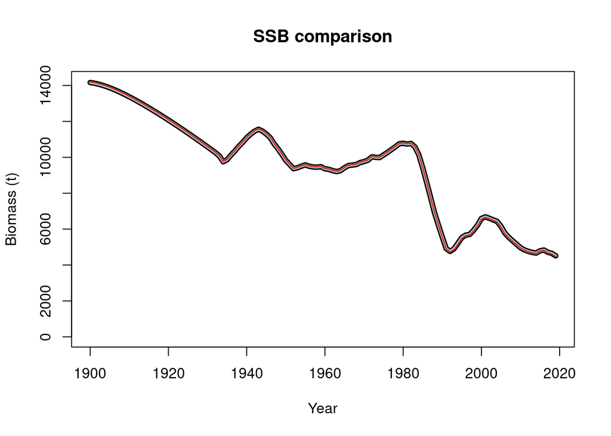

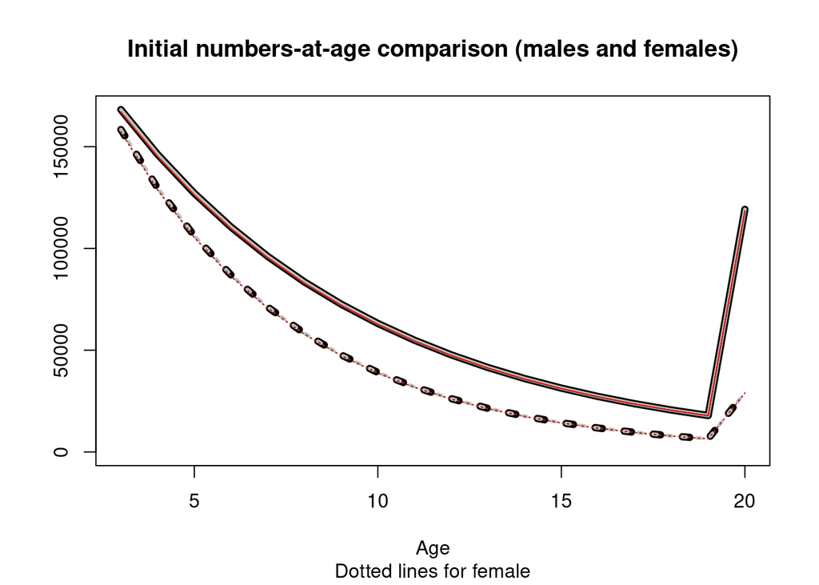

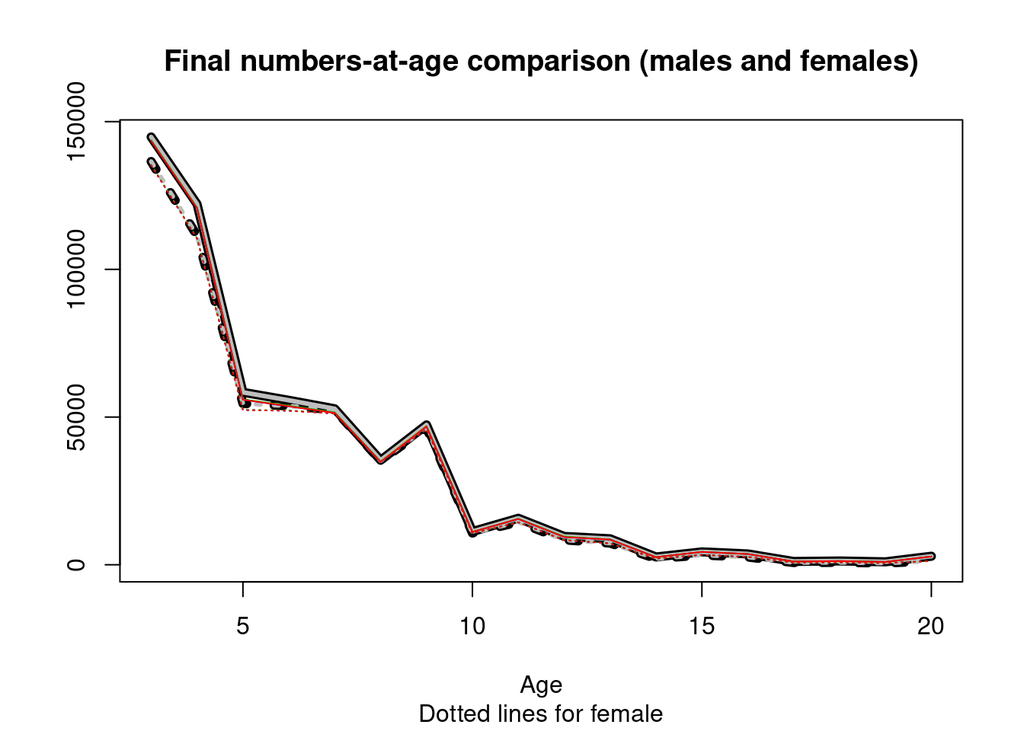

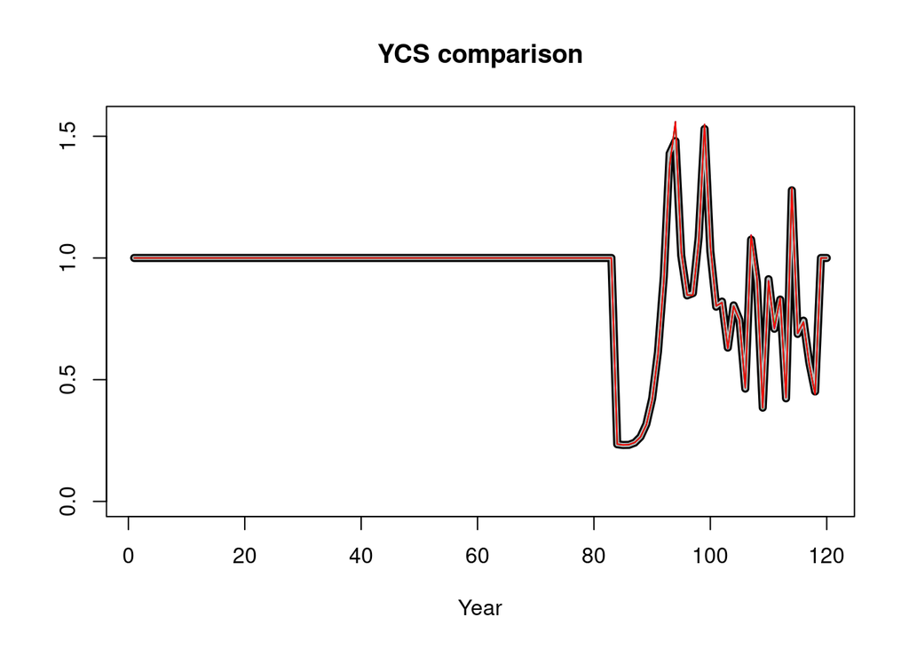

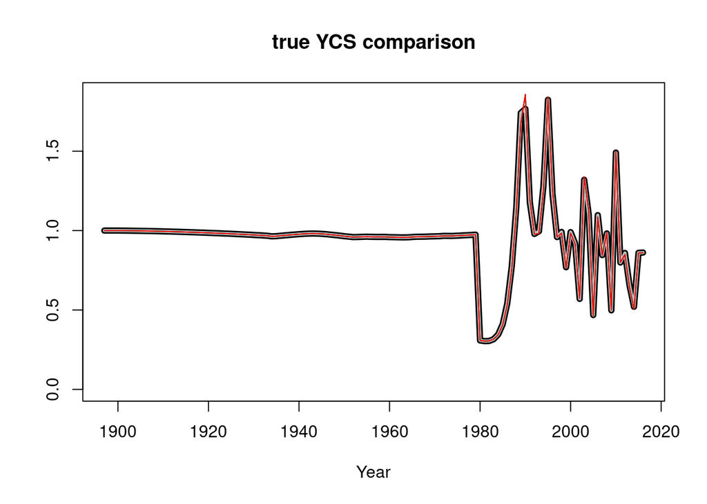

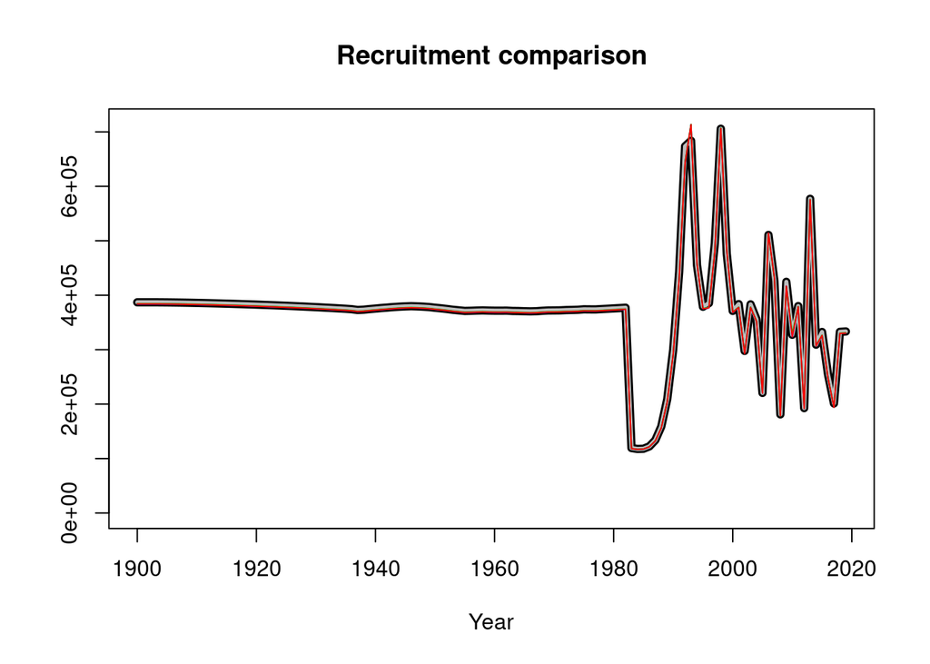

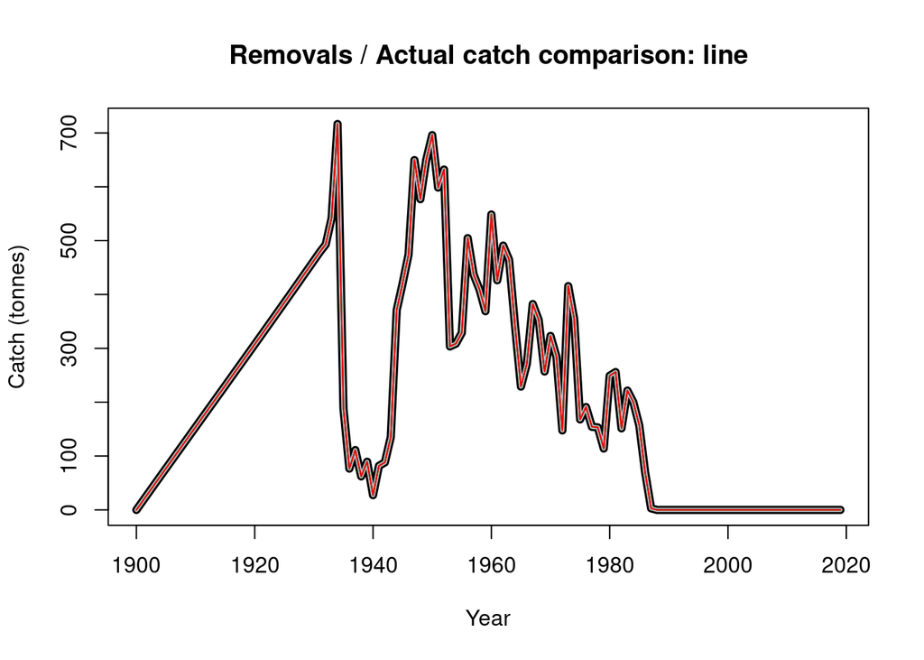

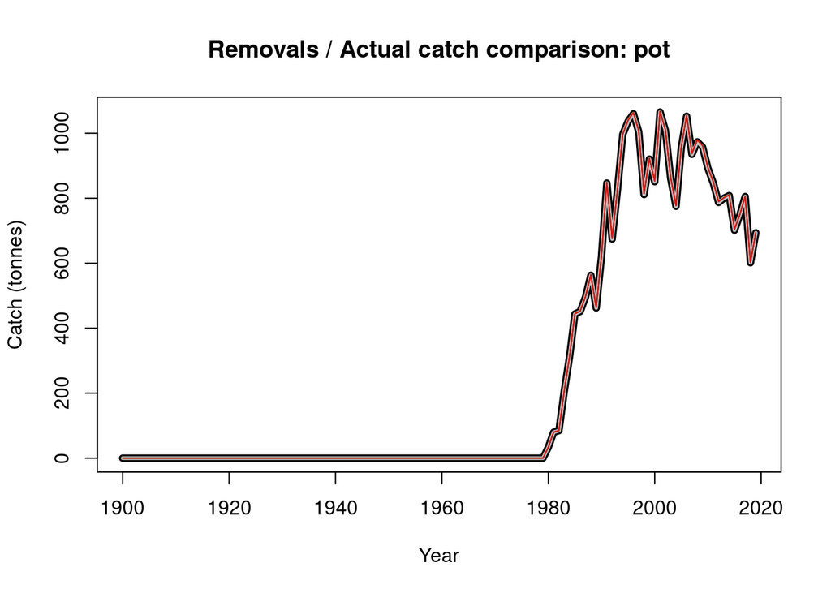

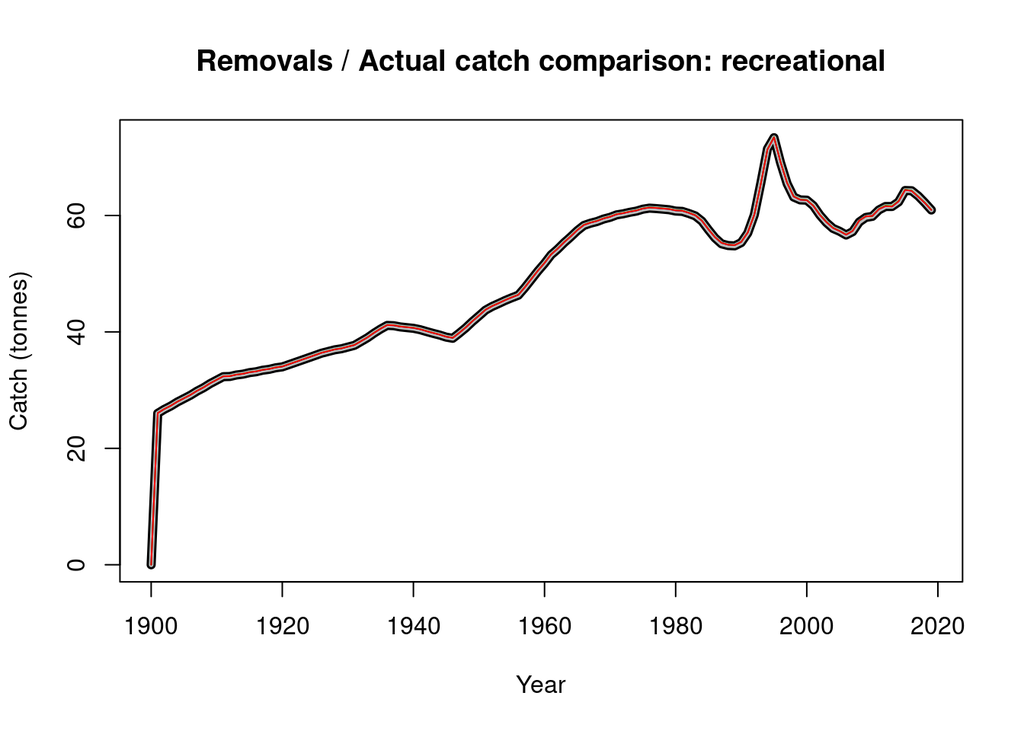

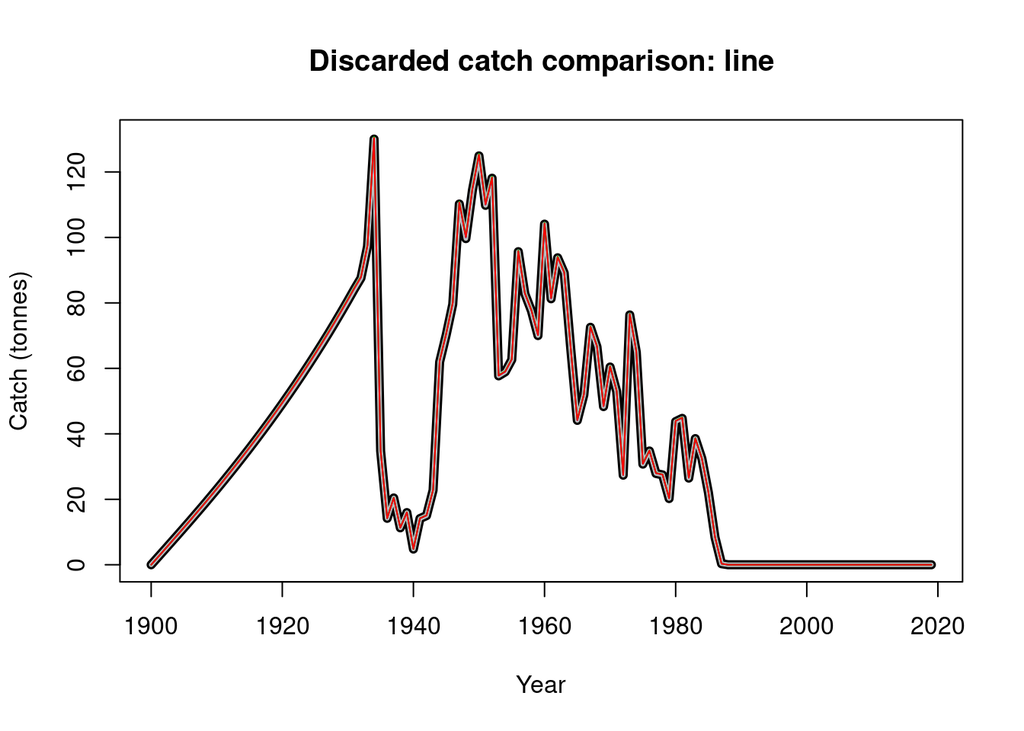

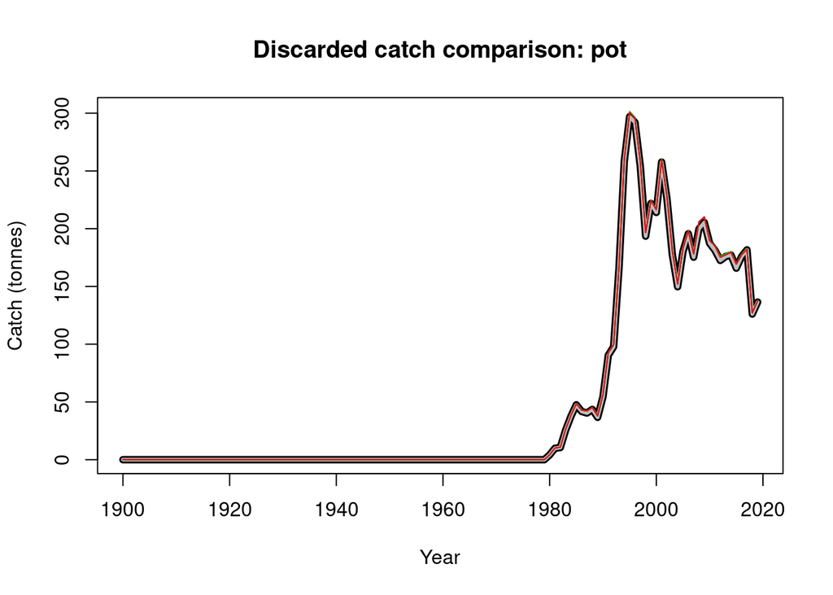

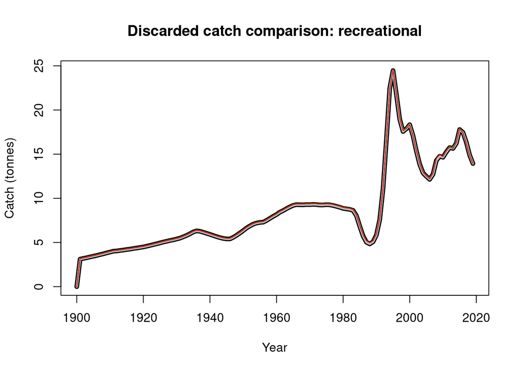

[4 more figures not shown]